# Clustering

[GitHub Repo](https://github.com/EvanMcCormick37/Text-Mining-Research-Project-Spring-2024)

# Clustering the Data

One important step in analyzing this large amount of text data is sorting it into groups. While some of my data comes pre-sorted into various labelled groups, much of the data (specifically the NewsAPI and WorldNewsAPI datasets) are un-grouped. For this data, I'll be using an unsupervised learning technique known as **clustering** to group the data into groups, or *clusters*.

### K-Means Clustering

One of the most straightforward methods for clustering is known as K-means clustering. I'm going to try clustering the World-News API data into labelled groups by using k-means clustering on the text TFIDF 1-gram word-document matrix.

```python
#Imports
import pandas as pd
import numpy as np
#preprocessing tools
from sklearn.preprocessing import normalize
#KMeans clustering tools
from sklearn.metrics import silhouette_score
from sklearn.cluster import KMeans
#for visualization
import seaborn as sns
import matplotlib.pyplot as plt
from wordcloud import WordCloud
```

```python
#Adding the Documents
world_news = pd.read_csv('../data/wdms/tfidf/worldnewsapi/lemmed/text.csv',index_col=0).fillna(0)

wdm = world_news.iloc[:,4:].astype(float)
print(wdm.head())
```

```
      said  transgender    school     woman    people    gender    state  \
0  0.00000     0.036492  0.000000  0.000000  0.000000  0.000000  0.00000
1  0.00000     0.133365  0.000000  0.032504  0.041765  0.077433  0.00000
2  0.00000     0.191680  0.000000  0.000000  0.147844  0.015663  0.00000
3  0.01885     0.101382  0.074511  0.000000  0.008648  0.057724  0.10919
4  0.00000     0.042000  0.000000  0.001852  0.055534  0.000000  0.00000

     trans     child       law  ...  procedure     known  vote  clear  \
0  0.00000  0.000000  0.000000  ...        0.0  0.000000   0.0    0.0
1  0.04162  0.006153  0.006663  ...        0.0  0.009177   0.0    0.0
2  0.00000  0.009334  0.000000  ...        0.0  0.000000   0.0    0.0
3  0.00000  0.045866  0.000000  ...        0.0  0.000000   0.0    0.0
4  0.00000  0.000000  0.000000  ...        0.0  0.000000   0.0    0.0

     making      cent      role  got     today     study
```

[output cut: 28 more lines]

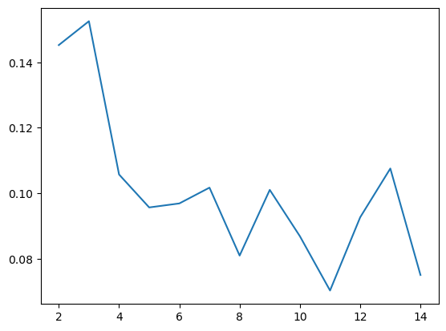

```python
scores=[]
for i in range(2,15):
    km=KMeans(n_clusters=i,n_init='auto')
    km.fit(wdm)
    labels=km.predict(wdm)
    # print(labels)
    scores+=[silhouette_score(wdm,labels)]
sns.lineplot(x=range(2,15),y=scores)
```

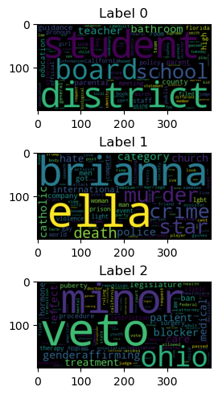

```python
#It appears that the silhouette score is maximized round n=3, so we'll go with that one for now.
# Now let's visualize the categories that have emerged.
km=KMeans(n_clusters=3,n_init='auto')
km.fit(wdm)
wdm['labels']=km.predict(wdm)
#Make a DF for the categorical term frequencies
wc_sums=pd.DataFrame(columns=wdm.columns)
#Each row of this df is a sum of the portion of the wdm which fits one category.
for l in range(3):
    wc_sums.loc[len(wc_sums.index)]=wdm[wdm['labels']==l].sum()
# Divide the dataframe by the mean along the y axis to get the relative frequencies of each term in each category
# compared to the average term frequency across the whole corpus.
wc_sums = wc_sums/wc_sums.mean()

wordclouds=[]
fig,ax=plt.subplots(3,1,constrained_layout=True)
for i in range(3):
    sums = wc_sums.iloc[i,:].sort_values(ascending=False)[:100]
    wordclouds += [WordCloud().generate_from_frequencies(sums)]
#Build the WordClouds
for i in range(3):
    ax[i].imshow(wordclouds[i])
    ax[i].set_title("Label "+str(i))
```

# Patterns Emerging

K-Means has found three distinct clusters, each focused around a *roughly* distinct subject.

```
* Ron DeSantis and the Florida bathroom bill appears to be one cluster.
* The Brianna Ghey killing and possibly another British news story about a reality-TV celebrity named Ella Morgan Clark, though I'm not sure.
* The most clear-cut category. The Ohio Senate recently passed a bundle of laws relating to this issue, banning the use of 'gender-affirming care' on minors, with an emphasis on hormone blockers, as well as restricting athletes from competing in gender divisions other then the gender they were assigned at birth.
```

Let's run it another time to see if the same categories emerge.

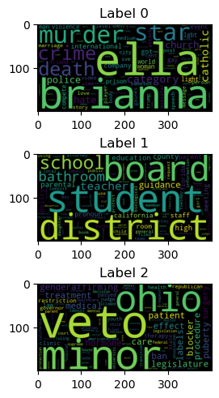

```python
#It appears that the silhouette score is maximized round n=3, so we'll go with that one for now.
# Now let's visualize the categories that have emerged.
km=KMeans(n_clusters=3,n_init='auto')
km.fit(wdm)
wdm['labels']=km.predict(wdm)
#Make a DF for the categorical term frequencies
wc_sums=pd.DataFrame(columns=wdm.columns)
#Each row of this df is a sum of the portion of the wdm which fits one category.
for l in range(3):
    wc_sums.loc[len(wc_sums.index)]=wdm[wdm['labels']==l].sum()
# Divide the dataframe by the mean along the y axis to get the relative frequencies of each term in each category
# compared to the average term frequency across the whole corpus.
wc_sums = wc_sums/wc_sums.mean()

wordclouds=[]
fig,ax=plt.subplots(3,1,constrained_layout=True)
for i in range(3):
    sums = wc_sums.iloc[i,:].sort_values(ascending=False)[:100]
    wordclouds += [WordCloud().generate_from_frequencies(sums)]
#Build the WordClouds
for i in range(3):
    ax[i].imshow(wordclouds[i])
    ax[i].set_title("Label "+str(i))
```

### They do!

This time, the three topics appear in a different order, with Brianna Ghey/Ella (we'll call this topic Great Britian) as topic 0, Florida as number 1, and Ohio as number 2.